# Quiz 1: Part 2

## Part 2: Coding in action

### Instructions

Please answer these questions in R using whatever syntax makes sense to you. Feel free to use the R help pages and/or notes from class.

**If you use Google or ChatGPT etc. to help you get to an answer, please note so on your answer**

Submit your answers as an html file. Name it “lastname_quiz1.html”. Two submission options:  
1. Email to mcnew@arizona.edu 2. Create a branch in your forked-and-cloned class repo. Add the html file to the student_contributions/ folder. Submit a pull request to Sabrina (extra credit).

```r
# load packages and data
library(dslabs)
library(dplyr)
library(tidyverse)
```

#### Load your data:

Load the *swallows.csv* into R, call it swallows. This data frame lists results of an experiment on tree swallows. Each row is a nest. Nests were put into one of two **treatments**: simulated predation (predator), or control (control). Along with treatment you have the following columns:  
**nest_fate** = whether the nest fledged any young or whether they all died  
**brood** = number of nestlings  
**n_fledged** = number of nestlings that fledged.

You also have a separate data frame called *brightness.csv* where each row lists the plumage brightness (a sexual signal) for the female at each nest. Load this one up too.

```r
# Answer
swallows <- read.csv("../quiz/swallows.csv")
brightness <- read.csv("../quiz/brightness.csv")


# Google? n
```

#### Wrangle your data

You realize that you want to add brightness information onto your main swallows data frame. Join these data frames using nest_id as your key variable. Describe how you would check to make sure this join worked as intended.

```r
#Answer

combined <- merge(swallows, brightness, by = "nestbox") # creates the combined data frame
combined # here I ran this to check if the brightness column was included in the data frame
```

```
   nestbox treatment brood n_fledged brightness
1    1_104 Predation     0         0       35.3
2     1_12   Control     6         1       50.6
3    1_121 Predation     6         2       33.9
4    1_123 Predation     5         0       42.4
5     1_17 Predation     5         0       53.6
6     1_62 Predation     1         0       56.0
7     1_81   Control     5         4       55.9
8     1_85   Control     4         2       57.0
9     1_91 Predation     5         4       56.2
10   2_102   Control     5         4       62.6
11   2_105 Predation     7         0       55.8
12   2_109 Predation     5         2         NA
13   2_114 Predation     6         1       57.0
14   2_117 Predation     6         5       59.2
```

[output cut: 28 more lines]

```r
# you can also look in the environment section if "combined" is a data fram with 42 observations of 5 variables

# Google? y
```

Inspect your combined data frame. Do some sort of quick sanity check on each column to catch any obvious entry errors. Correct as necessary

```r
# Answer
str(combined)  # see whether each column is a character, integer, etc
```

```
'data.frame':   42 obs. of  5 variables:
 $ nestbox   : chr  "1_104" "1_12" "1_121" "1_123" ...
 $ treatment : chr  "Predation" "Control" "Predation" "Predation" ...
 $ brood     : int  0 6 6 5 5 1 5 4 5 5 ...
 $ n_fledged : int  0 1 2 0 0 0 4 2 4 4 ...
 $ brightness: num  35.3 50.6 33.9 42.4 53.6 56 55.9 57 56.2 62.6 ...
```

```r
unique(combined$treatment)  # make sure there are no typos!
```

```
[1] "Predation" "Control"
```

```r
sort(combined$brood) # visually see if there are any numbers that are negative or huge
```

```
 [1] 0 0 0 1 1 2 2 2 3 3 4 4 5 5 5 5 5 5 5 5 5 5 5 5 5 5 5 5 5 5 5 6 6 6 6 6 6 6
[39] 6 6 6 7
```

```r
sort(combined$n_fledged) # same as above
```

```
 [1] 0 0 0 0 0 0 0 0 0 0 0 0 0 1 1 1 1 1 2 2 2 2 2 2 2 2 3 3 4 4 4 4 4 4 4 5 5 5
[39] 5 5 5 6
```

```r
# Google n
```

Create a new column called prop_fledged that contains the proportion of nestlings that fledged from each nest.

```r
#Answer
combined <- mutate(combined, prop_fledged = n_fledged/brood)
combined # check that it looks good
```

```
   nestbox treatment brood n_fledged brightness prop_fledged
1    1_104 Predation     0         0       35.3          NaN
2     1_12   Control     6         1       50.6    0.1666667
3    1_121 Predation     6         2       33.9    0.3333333
4    1_123 Predation     5         0       42.4    0.0000000
5     1_17 Predation     5         0       53.6    0.0000000
6     1_62 Predation     1         0       56.0    0.0000000
7     1_81   Control     5         4       55.9    0.8000000
8     1_85   Control     4         2       57.0    0.5000000
9     1_91 Predation     5         4       56.2    0.8000000
10   2_102   Control     5         4       62.6    0.8000000
11   2_105 Predation     7         0       55.8    0.0000000
12   2_109 Predation     5         2         NA    0.4000000
13   2_114 Predation     6         1       57.0    0.1666667
14   2_117 Predation     6         5       59.2    0.8333333
```

[output cut: 28 more lines]

```r
# Google? n
```

#### Explore the data

What was the mean proportion of nestlings fledged in each treatment?

```r
# Answer
mean_prop <- combined %>%
  filter(prop_fledged != "NaN") %>%
  summarize(average = mean(prop_fledged))
mean_prop
```

```
    average
1 0.5059829
```

```r
# The mean proportion is 0.5059829


# Google? n
```

Create a plot showing fledging success differences between treatments

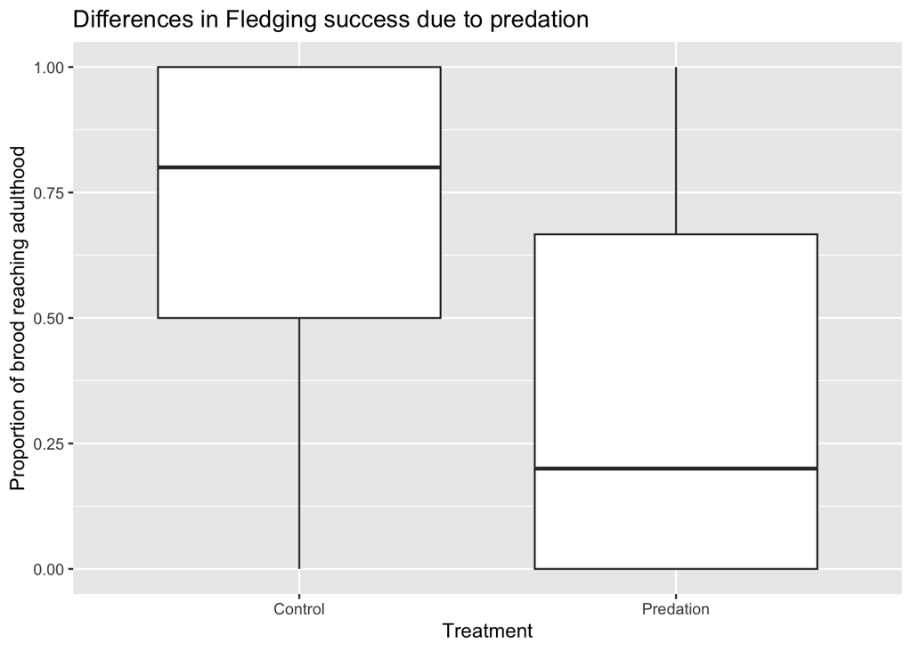

```r
#Answer
fledgingtreatment <- ggplot(data = combined, aes(x = treatment, y = prop_fledged)) +
  labs(title = "Differences in Fledging success due to predation", x = "Treatment", y = "Proportion of brood reaching adulthood") +
  geom_boxplot()

fledgingtreatment
```

```r
# Google? n
```

Is there any evidence that female brightness influenced fledging success? Create a plot to visually investigate this question.

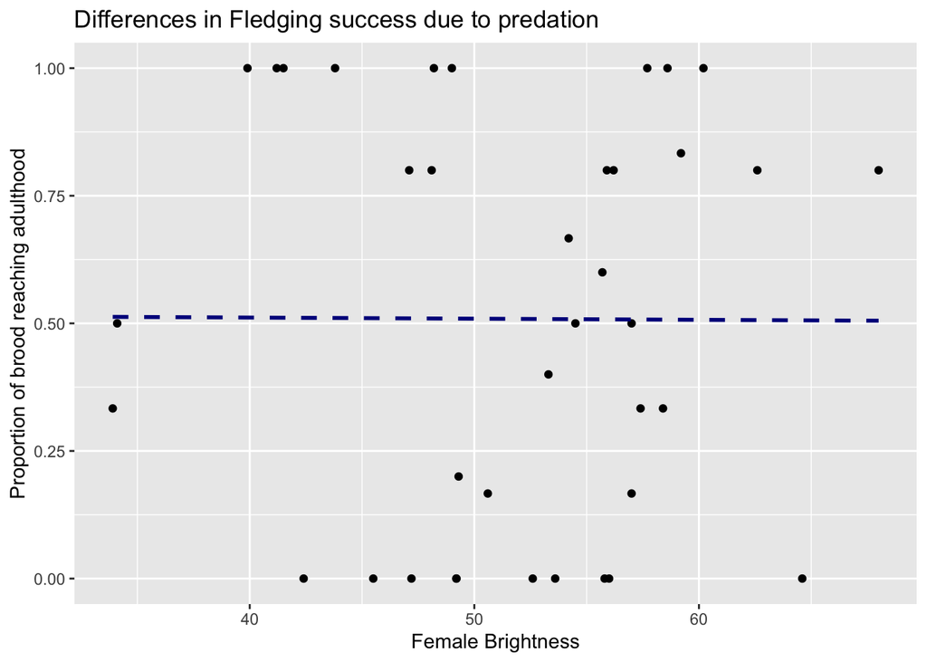

```r
#Answer

fledgingbrightness <- ggplot(combined, aes(x=brightness, y=prop_fledged)) +
  labs(title = "Differences in Fledging success due to predation", x = "Female Brightness", y = "Proportion of brood reaching adulthood") +
  geom_point() +
  geom_smooth(method=lm, se = FALSE, linetype = "dashed", color = "darkblue")

fledgingbrightness    # There is no evidence that brightness influences fledging success
```

```r
# Google? y
```